# Covid 19 Analysis

Dawson Tam

2023-07-06

Abstract

In an effort to undertsand the impact of Covid-19 on the world, I will analyze the multiple facets of covid related deaths and compare them across variables I deem relevant. Additionally, I want to measure whether or not states with higher vaccine rates see a lower death rate to prove the effectiviness of vaccines.

```r
library(tidyverse)
library(dplyr)
library(skimr)
library(Hmisc)
```

```r
library(ggplot2)
```

summarizing the global data to see which parts of the data sheet need cleaning and processing

```r
Covid_19_rates <- read.csv("/Users/dawsontam/Desktop/COVID19_line_list_data.csv")
describe(Covid_19_rates)
```

```
## Covid_19_rates
##
##  27  Variables      1085  Observations
## --------------------------------------------------------------------------------
## id
##        n  missing distinct     Info     Mean      Gmd      .05      .10
##     1085        0     1085        1      543      362     55.2    109.4
##      .25      .50      .75      .90      .95
##    272.0    543.0    814.0    976.6   1030.8
##
## lowest :    1    2    3    4    5, highest: 1081 1082 1083 1084 1085
## --------------------------------------------------------------------------------
## case_in_country
##        n  missing distinct     Info     Mean      Gmd      .05      .10
##      888      197      197        1    48.84    54.99     2.00     4.00
##      .25      .50      .75      .90      .95
##    11.00    28.00    67.25   110.30   153.65
##
## lowest :    1    2    3    4    5, highest:  365  443  875  925 1443
## --------------------------------------------------------------------------------
## reporting.date
##        n  missing distinct
##     1084        1       43
##
## lowest : 02/01/20  02/02/20  02/03/20  02/04/20  02/05/20
## highest: 2/24/2020 2/25/2020 2/26/2020 2/27/2020 2/28/2020
## --------------------------------------------------------------------------------
## summary
##        n  missing distinct
##     1080        5      967
##
## lowest : confirmed COVID-19 pneumonia patient No.11 in Tianjin: female, 55, symptom onset on 01/23/2020, hospitalized on 01/23/2020, confirmed on 01/26/2020                                                                                                 confirmed COVID-19 pneumonia patient No.12 i…
## highest: new recovered imported COVID-19 pneumonia patient in Beijing: female, returned to Beijing from Wuhan on 01/08/2020, symptom onset afterwards, recovered on 01/24/2020.                                                                              new recovered imported COVID-19 pneumonia pa…
## --------------------------------------------------------------------------------
## location
##        n  missing distinct
##     1085        0      156
##
## lowest : Afghanistan      Aichi Prefecture Alappuzha        Algeria          Amiens
## highest: Yunnan           Zabaikalsky      Zaragoza         Zhejiang         Zhuhai
```

[output cut: 93 more lines]

```
##
## lowest : ABC                 ABC News            Al Arabiya          Aljazeera           Bangkok Post
## highest: Yonnhap News Agency 人民日报            人民日报官方微博    央视新闻            新浪
## --------------------------------------------------------------------------------
## link
##        n  missing distinct
##     1085        0      490
##
## lowest : http://behdasht.gov.ir/news/%DA%A9%D8%B1%D9%88%D9%86%D8%A7+%D9%88%DB%8C%D8%B1%D9%88%D8%B3/199807/%D8%AF%D8%B1+%D8%B1%D9%88%D8%B2%D9%87%D8%A7%DB%8C+%DA%AF%D8%B0%D8%B4%D8%AA%D9%87+735+%D8%A8%DB%8C%D9%85%D8%A7%D8%B1+%D8%A8%D8%A7+%D8%B9%D9%84%D8%A7%D8%A6%D9%85+%D8%B4%D8%A8%D9%87+%D8%A2%D9%86…
## highest: https://www3.nhk.or.jp/nhkworld/en/news/20200116_23/                                                                                                                                                                                                                                            …
## --------------------------------------------------------------------------------
##
## Variables with all observations missing:
##
## [1] X   X.1 X.2 X.3 X.4 X.5 X.6
```

Add new column to dataframe as current “death” column is inconsistent. After using describe(), I noticed that there are 14 values for “death”. To combat, I will create this new column that standardizes “death”.

updated dataframe

```r
Covid_19_rates$death_updated <- as.integer(Covid_19_rates$death != 0)
unique(Covid_19_rates$death_updated)
```

```
## [1] 0 1
```

```r
head(Covid_19_rates, 4)
```

```
##   id case_in_country reporting.date  X
## 1  1              NA      1/20/2020 NA
## 2  2              NA      1/20/2020 NA
## 3  3              NA      1/21/2020 NA
## 4  4              NA      1/21/2020 NA
##                                                                                                                                                                                                                                                                                                          …
## 1 First confirmed imported COVID-19 pneumonia patient in Shenzhen (from Wuhan): male, 66, shenzheng residence, visited relatives in Wuhan on 12/29/2019, symptoms onset on 01/03/2020, returned to Shenzhen and seek medical care on 01/04/2020, hospitalized on 01/11/2020, sample sent to China CDC for…
## 2                                                                                                                                                                    First confirmed imported COVID-19 pneumonia patient in Shanghai (from Wuhan): female, 56, Wuhan residence, arrived in Shanghai from …
## 3                                                                                                                                        First confirmed imported cases in Zhejiang: patient is male, 46, lives in Wuhan, self-driving from Wuhan to Hangzhou on 01/03/2020, symptom onset 01/04/2020, ho…
## 4                                                                                                                                                                                                                                            new confirmed imported COVID-19 pneumonia in Tianjin: female…
##              location country gender age symptom_onset If_onset_approximated
## 1 Shenzhen, Guangdong   China   male  66      01/03/20                     0
## 2            Shanghai   China female  56     1/15/2020                     0
## 3            Zhejiang   China   male  46      01/04/20                     0
## 4             Tianjin   China female  60          <NA>                    NA
```

[output cut: 20 more lines]

First, I would like to compare the mean age of the people that are alive with covid versus the mean age of those who have contracted covid and have died. I hyothesize that of those who have contracted covid, there is a greater chance someone will die if they are older.

```r
alive_subset <- subset(Covid_19_rates, death_updated == 0)
dead_subset <- subset(Covid_19_rates, death_updated == 1)
alive_mean <- mean(alive_subset$age, na.rm = TRUE)
dead_mean <- mean(dead_subset$age, na.rm = TRUE)
dead_mean > alive_mean
```

```
## [1] TRUE
```

My claim is true as we see that the average age of those who died is greater than the average age of those who are still alive.

Next, I want to compare covid related deaths in male versus females to see if there is a difference in mortality rate. By conudcting a t-test, I can determine whether or not this result is signficant. For this t-test, our null hypothesis is that the death rates for male and females are the same and the alternative hypothesis is that they are different. In order to keep all of my test consistent, I will be using a p-value of 0.05.

```r
t.test(death_updated ~ gender, data = Covid_19_rates)
```

```
##
##  Welch Two Sample t-test
##
## data:  death_updated by gender
## t = -3.084, df = 894.06, p-value = 0.002105
## alternative hypothesis: true difference in means between group female and group male is not equal to 0
## 95 percent confidence interval:
##  -0.07849151 -0.01744083
## sample estimates:
## mean in group female   mean in group male
##           0.03664921           0.08461538
```

As we can see from our results, the mean death rate for males is 0.0846 while the mean death rates for females is 0.0366, which at first glance is drastically different. Our t-test also proves so, as we get a resulting p-value of 0.002. Because 0.002 < 0.05, we can comfortably reject our null hypothesis and conlcude that our results our statistically significant and that the death rates do indeed vary between male and females.

Another variable that this data set provides it “Visiting Wuhan” expressed as a binary variable. As Wuhan is commonly believed to have orginated in Wuhan China, I thought it would be interesting to test whether or not the death rates in Wuhan were higher than that of the death rates not in Wuhan. Once again, I will be using a two sample t-test with p value of 0.05 to test my hypothesis.

The null hypothesis is that death rates inside Wuhan and outside Wuhan are the same but the alternative hypothesis is that the two are different.

I begin by making two new subset from from.Wuhan to compare the mean of death rates in these two categories

```r
from_wuhan = subset(Covid_19_rates, from.Wuhan == 1)
nfrom_wuhan = subset(Covid_19_rates, from.Wuhan == 0)
mean(from_wuhan$death_updated, na.rm = TRUE)
```

```
## [1] 0.2179487
```

```r
mean(nfrom_wuhan$death_updated, nam.rm = TRUE)
```

```
## [1] 0.03135135
```

```r
t.test(from_wuhan$death_updated, nfrom_wuhan$death_updated)
```

```
##
##  Welch Two Sample t-test
##
## data:  from_wuhan$death_updated and nfrom_wuhan$death_updated
## t = 5.5447, df = 164.38, p-value = 1.152e-07
## alternative hypothesis: true difference in means is not equal to 0
## 95 percent confidence interval:
##  0.1201495 0.2530453
## sample estimates:
##  mean of x  mean of y
## 0.21794872 0.03135135
```

As we can see from our t-test above, the p-value is extremely small and incomparable to our p-value of 0.05. Thus we can conclude that rejct the null hypothesis and conclude that death rates are in fact different in and out of Wuhan.

The second part of this analysis is to measure the effectiveness of vaccines in regards to prevent covid related deaths.

```r
usa_vaccines <- read.csv("/Users/dawsontam/Desktop/us_state_vaccinations.csv")
states <- read.csv("/Users/dawsontam/Desktop/states.csv")
describe(usa_vaccines)
```

```
## usa_vaccines
##
##  16  Variables      54628  Observations
## --------------------------------------------------------------------------------
## date
##        n  missing distinct
##    54628        0      872
##
## lowest : 2020-12-20 2020-12-21 2020-12-22 2020-12-23 2020-12-24
## highest: 2023-05-06 2023-05-07 2023-05-08 2023-05-09 2023-05-10
## --------------------------------------------------------------------------------
## location
##        n  missing distinct
##    54628        0       65
##
## lowest : Alabama        Alaska         American Samoa Arizona        Arkansas
## highest: Virginia       Washington     West Virginia  Wisconsin      Wyoming
## --------------------------------------------------------------------------------
## total_vaccinations
##        n  missing distinct     Info     Mean      Gmd      .05      .10
##    32532    22096    30797        1 11851991 18680595    52311   115141
##      .25      .50      .75      .90      .95
##   927731  3199256  7948546 15837354 27258094
##
## lowest :       416       424       565       605       639
## highest: 674024493 675024615 675442636 676006980 676728782
## --------------------------------------------------------------------------------
## total_distributed
##        n  missing distinct     Info     Mean      Gmd      .05      .10
##    32272    22356    22765        1 14988322 23672190    71460   147460
##      .25      .50      .75      .90      .95
##  1188560  4051065 10064899 20590352 35119553
##
## lowest :      6000      9175      9200      9575      9800
## highest: 973224305 978124175 979617855 982117925 984444295
## --------------------------------------------------------------------------------
## people_vaccinated
##        n  missing distinct     Info     Mean      Gmd      .05      .10
##    32268    22360    30966        1  5909278  9253052    30112    65908
##      .25      .50      .75      .90      .95
```

[output cut: 82 more lines]

```
##    18116    36512    17291        1  2581003  4161231     6387    19299
##      .25      .50      .75      .90      .95
##   145342   605864  1799718  3570672  6393894
##
## lowest :        11        14        15        34        39
## highest: 190790403 191668184 191961979 192394539 192964188
## --------------------------------------------------------------------------------
## total_boosters_per_hundred
##        n  missing distinct     Info     Mean      Gmd      .05      .10
##    17254    37374     5656        1    25.51     19.9     1.45     2.82
##      .25      .50      .75      .90      .95
##    10.29    24.78    36.80    48.07    57.38
##
## lowest : 0      0.01   0.02   0.03   0.04  , highest: 103.01 103.16 103.34 103.66 104.04
## --------------------------------------------------------------------------------
```

I will now get the mean number of people vaccinated grouped by their state in order to compare the vaccination rate across the state.

```r
grouped_us_vaccines <- usa_vaccines %>% group_by(location) %>% summarise(mean_total_vaccinated = mean(people_vaccinated, na.rm = TRUE))
grouped_us_vaccines <- grouped_us_vaccines[grouped_us_vaccines$location %in%  states$State, ]
grouped_us_vaccines$state_code <- state.abb[match(grouped_us_vaccines$location, state.name)]
grouped_us_vaccines_abb <- grouped_us_vaccines[,-c(1)]
grouped_us_vaccines_abb <- grouped_us_vaccines_abb %>% replace(is.na(.), "NY"   )
grouped_us_vaccines_abb <- grouped_us_vaccines_abb[order(grouped_us_vaccines_abb$state_code),]
colnames(grouped_us_vaccines_abb)[2] = "State"
```

In order to get the death rates, I will have to import another dataset.

```r
death_rates <- read.csv("/Users/dawsontam/Desktop/covid_deaths_usafacts.csv")
death_rates_2021_2022 <- death_rates[,-4:-349]
no_na <- death_rates_2021_2022 %>% replace(is.na(.), 0)
no_na$sum_of_row <- rowSums(no_na[, c(4:ncol(no_na))])
cleaned <- no_na[, c("State", "sum_of_row")]
```

```r
meaned_deaths_per_state <- cleaned %>% group_by(State) %>% summarise(mean_death = mean(sum_of_row))
ordered_mean_deaths <- meaned_deaths_per_state[order(meaned_deaths_per_state$State),]
ordered_mean_deaths <- ordered_mean_deaths[-8, ]
```

However, it is important to note that different states have different populations so in order to standardize everything I have to import a 2021 - 2022 per state populations dataset.

```r
populations <- read.csv("/Users/dawsontam/desktop/NST_EST2022_POP_1_2.csv")
colnames(populations)[1] = "State"
new_populations <- populations[,-c(2:5) ]
new_populations <- new_populations[order(new_populations$State), ]
new_populations <- new_populations[-1, ]
```

```r
standardized_death <- merge(x = ordered_mean_deaths, y = new_populations, by = "State", all = TRUE)
standardized_death <- standardized_death %>% replace(is.na(.), 778597.5 )
final_standard_death <- standardized_death[-35, ]
final_standard_death$standard_death <- final_standard_death$mean_death / final_standard_death$mean_2021_2022
```

Now that I have my standardized death rates for the 50 states, I can begin a linear regression analysis to see whether not we see a negative correlation between vaccine and death rates.

```r
vaccines_vs_death <- merge(x = final_standard_death, y = grouped_us_vaccines_abb, by = "State", all = TRUE)
lmvaccine_death <- lm(formula = mean_total_vaccinated ~ standard_death, data = vaccines_vs_death)
summary(lmvaccine_death)
```

```
##
## Call:
## lm(formula = mean_total_vaccinated ~ standard_death, data = vaccines_vs_death)
##
## Residuals:
##      Min       1Q   Median       3Q      Max
## -3546478 -2369203 -1114911  1128423 19687419
##
## Coefficients:
##                Estimate Std. Error t value Pr(>|t|)
## (Intercept)     3945886     728347   5.418 1.92e-06 ***
## standard_death -6144646    5784551  -1.062    0.293
## ---
## Signif. codes:  0 '***' 0.001 '**' 0.01 '*' 0.05 '.' 0.1 ' ' 1
##
## Residual standard error: 4143000 on 48 degrees of freedom
## Multiple R-squared:  0.02297,    Adjusted R-squared:  0.002613
## F-statistic: 1.128 on 1 and 48 DF,  p-value: 0.2934
```

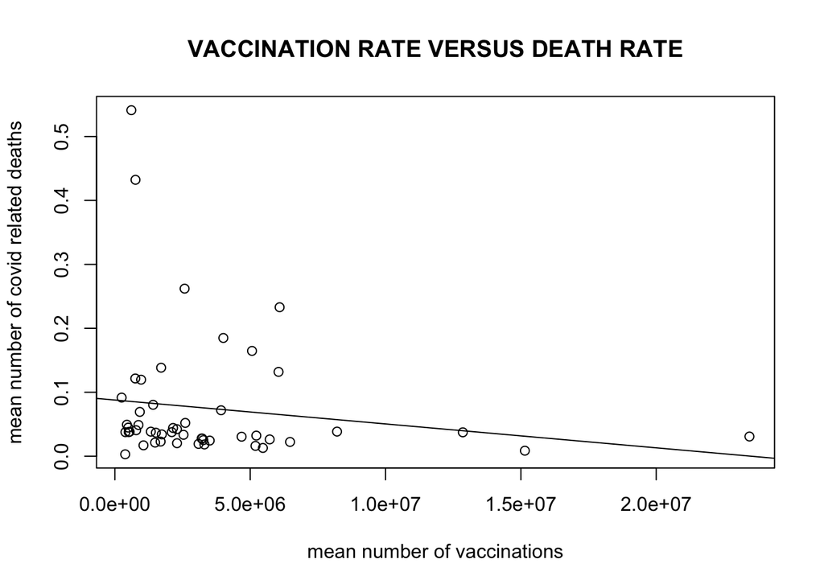

```r
plot(standard_death ~ mean_total_vaccinated, data = vaccines_vs_death, main = "VACCINATION RATE VERSUS DEATH RATE", xlab = "mean number of vaccinations", ylab = "mean number of covid related deaths")
abline(lm(standard_death ~ mean_total_vaccinated, data = vaccines_vs_death))
```